# Practical Machine Learning: Prediction Assignment Writeup

Kuprashevich Maksim

*My native lang is not english, but I will try my best*

This is report for [Practical Machine Learning](https://class.coursera.org/predmachlearn-016) course on Coursera about study [Weight Lifting Exercises Dataset](http://groupware.les.inf.puc-rio.br/har)

For some errors that I can’t solve, train function in Caret package doesn’t work with that data, so in this research I used old package for SVM **e1071**.

```
# Loading train and test data from files
train <- read.csv(file="pml-training.csv", head=TRUE, sep=",")
test <- read.csv(file="pml-testing.csv", head=TRUE, sep=",")
```

First of all, I’ve found in data useless (in my opinion) columns and NA values that I wish to be removed, so I defined function:

```
clean_data = function(x) {
  x <- x[, which(colSums(apply(x, 2, is.na)) == 0)]
  x <- x[, -which(names(x) %in% c("new_window","num_window", "cvtd_timestamp", "X", "user_name"))]
  return(x)
}

# Clean unuseful NA's and columns
train <- clean_data(train)
test <- clean_data(test)
```

Second moment I’ve noted - train and test datasets has different number of coulumns, so I did cross sync (with saving classe column):

```
classe_column <- train$classe
test <- test[ , which(names(test) %in% names(train))]
train <- train[ , which(names(train) %in% names(test))]
train["classe"] <- classe_column
```

Then I tried to find optimal values for SVM parameters with tuned function, that uses 10-fold cross validation with greedy search algorithm for best parameters:

```
# Get best parameters for SVM
tuned <- tune.svm(classe~., data = train, gamma = 10^(-6:-1), cost = 10^(1:2))
summary(tuned)
```

Output after 3 hours of work :) :

```
Parameter tuning of ‘svm’:
- sampling method: 10-fold cross validation
- best parameters:
 gamma cost
  0.1  100

- best performance: 0.002955933

- Detailed performance results:
  gamma cost       error  dispersion
1  1e-06   10 0.715675626 0.007197491
2  1e-05   10 0.491182545 0.011745177
3  1e-04   10 0.346855226 0.008049616
4  1e-03   10 0.148149092 0.007390940
5  1e-02   10 0.022424097 0.003050693
6  1e-01   10 0.004077082 0.001698800
7  1e-06  100 0.491488251 0.012069983
8  1e-05  100 0.351085006 0.007911848
9  1e-04  100 0.239678782 0.008431634
10 1e-03  100 0.061309065 0.005592526
11 1e-02  100 0.006574274 0.001740053
12 1e-01  100 0.002955933 0.001172241
```

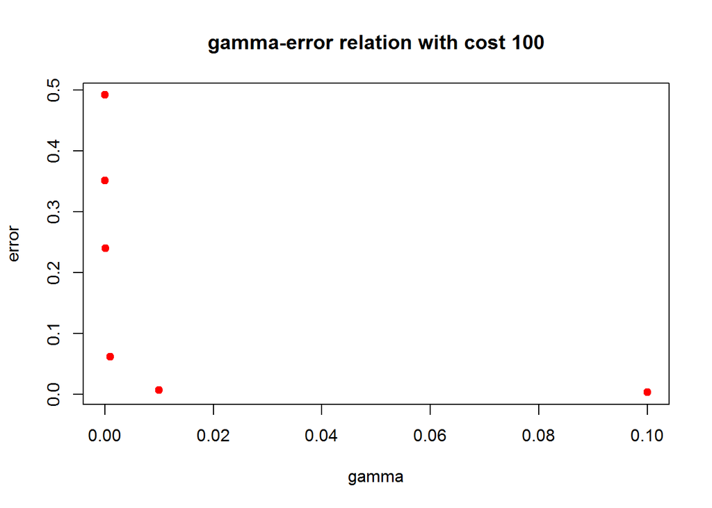

```r
plot(c(0.000001, 0.00001, 0.0001, 0.001, 0.01, 0.1), c(0.491488251, 0.351085006, 0.239678782, 0.061309065, 0.006574274, 0.002955933), type = "p", ylab = "error", xlab = "gamma", main = "gamma-error relation with cost 100", col = "red", pch = 19)
```

In such way I found best values for gamma `0.1` and cost `100`, with error `0.002955933` and dispersion `0.001172241`. That’s not bad.

Time for train model:

```
model  <- svm(classe~., data = train, kernel = "radial", gamma = 0.1, cost = 100)
```

And predict test dataset:

```
prediction <- predict(model, newdata = test)
```

Prediction results:

```
1  2  3  4  5  6  7  8  9 10 11 12 13 14 15 16 17 18 19 20
B  A  B  A  A  E  D  B  A  A  B  C  B  A  E  E  A  B  B  B
```

It’s 19 of 20 success predictions in Course Project Submission. Problem 11 failed, so seems that I missed something, but I dont know what. Right answer on that problem 11 is “C”, I found it with linear core SVM.